# DSC540 Project 1

DePaul University  
Ilyas Ustun, PhD  
Chicago, IL

```python
import sklearn
sklearn.__version__
```

```
'1.3.0'
```

```python
from sklearn.model_selection import train_test_split
from sklearn import metrics

import matplotlib.pyplot as plt
import pandas as pd
import numpy as np
import seaborn as sns
```

```python
pd.set_option('display.max_columns', 100)
```

### These are the packages I used

```python
# Your package imports here
```

```python
from sklearn.model_selection import learning_curve
from sklearn.svm import SVC
from sklearn.model_selection import GridSearchCV
import warnings
from sklearn.preprocessing import StandardScaler
warnings.filterwarnings('ignore', message="X does not have valid feature names")
from sklearn.neighbors import KNeighborsClassifier
from sklearn.metrics import accuracy_score, classification_report, confusion_matrix
```

# DSC540 Project 1

## Rules

- Do not change the code already present in the notebook.
- Write your code under the corresponding questions where you see `# Code here`. You can use more than one cell, if you'd like.
- Provide explanation in a separate Markdown formatted cell.
- You can change the cell type by:
  - Clicking on the outer area of the cell type you want to change,
  - Go to the top, and select either Code or Markdown from the dropdown menu.
- Be concise in your explanations and conclusions.
- Write clear code and provide explanation to functions you create by using `#` comment sign.
- For built-in function and methods you use from libraries, provide a very brief explanation of what they do.
- Try to answer the questions by yourself. Use documentation from pandas, sklearn and similar libraries to solve the problem.
- If you are stuck you can use different resources. Do not find an identical project and copy paste the solutions.
- Write your name before beginning to code.

Important:

- **Do NOT share the solutions with other people.**
- **Do NOT share the solutions on the internet including but not limited to Github and other platforms.**
- Sign the Honor Pledge below indicating that you have agreed to these rules listed here, and any other ethical and honor rules as required by the university.
- **Deliverables:**
  1. The Python Jupyter notebook file named properly with your name. Example: dsc540_project1_john_doe.ipynb
  2. The HTML output of this code notebook names the same way. Example: dsc540_project1_john_doe.html
     - File -> Download as -> HTML

Good Luck!

### Nihar Muniraju

**Honor Pledge:**  
I pledge on my honor that I, **Nihar Muniraju**, have followed the rules listed above, that I have not given or received any unauthorized assistance on this assignment.

## The Data

In this project, we will be working with the **Breast Cancer Wisconsin dataset**, which contains 569 examples of malignant and benign tumor cells.  
The Breast Cancer Wisconsin dataset can be found in the UCI Machine Learning Repository, and more detailed information about this dataset can be found at https://archive.ics.uci.edu/ml/datasets/Breast+Cancer+Wisconsin+(Diagnostic).  
The first two columns in the dataset store the unique ID numbers of the examples and the corresponding diagnoses (M = malignant, B = benign), respectively.  
Columns 3-32 contain 30 real-valued features that have been computed from digitized images of the cell nuclei, which can be used to build a model to predict whether a tumor is benign or malignant.

**Variable Information:**

1) ID number 2) Diagnosis (M = malignant, B = benign) 3-32)

Ten real-valued features are computed for each cell nucleus:

```
a) radius (mean of distances from center to points on the perimeter)
b) texture (standard deviation of gray-scale values)
c) perimeter
d) area
e) smoothness (local variation in radius lengths)
f) compactness (perimeter^2 / area - 1.0)
g) concavity (severity of concave portions of the contour)
h) concave points (number of concave portions of the contour)
i) symmetry
j) fractal dimension ("coastline approximation" - 1)
```

The mean, standard error, and "worst" or largest (mean of the three largest values) of these features were computed for each image, resulting in 30 features. For instance, field 3 is Mean Radius, field 13 is Radius SE, field 23 is Worst Radius.

### Load the dataset

```python
df = pd.read_csv('wdbc.data', header=None)
df
```

|  | 0 | 1 | 2 | 3 | 4 | 5 | 6 | 7 | 8 | 9 | 10 | 11 | 12 | 13 | 14 | 15 | 16 | 17 | 18 | 19 | 20 | 21 | 22 | 23 | 24 | 25 | 26 | 27 | 28 | … |
| --- | --- | --- | --- | --- | --- | --- | --- | --- | --- | --- | --- | --- | --- | --- | --- | --- | --- | --- | --- | --- | --- | --- | --- | --- | --- | --- | --- | --- | --- | --- |
| 0 | 842302 | M | 17.99 | 10.38 | 122.80 | 1001.0 | 0.11840 | 0.27760 | 0.30010 | 0.14710 | 0.2419 | 0.07871 | 1.0950 | 0.9053 | 8.589 | 153.40 | 0.006399 | 0.04904 | 0.05373 | 0.01587 | 0.03003 | 0.006193 | 25.380 | 17.33 | 184.60 | 2019.0 | 0.16220 | 0.66560 | 0.7119 | … |
| 1 | 842517 | M | 20.57 | 17.77 | 132.90 | 1326.0 | 0.08474 | 0.07864 | 0.08690 | 0.07017 | 0.1812 | 0.05667 | 0.5435 | 0.7339 | 3.398 | 74.08 | 0.005225 | 0.01308 | 0.01860 | 0.01340 | 0.01389 | 0.003532 | 24.990 | 23.41 | 158.80 | 1956.0 | 0.12380 | 0.18660 | 0.2416 | … |
| 2 | 84300903 | M | 19.69 | 21.25 | 130.00 | 1203.0 | 0.10960 | 0.15990 | 0.19740 | 0.12790 | 0.2069 | 0.05999 | 0.7456 | 0.7869 | 4.585 | 94.03 | 0.006150 | 0.04006 | 0.03832 | 0.02058 | 0.02250 | 0.004571 | 23.570 | 25.53 | 152.50 | 1709.0 | 0.14440 | 0.42450 | 0.4504 | … |
| 3 | 84348301 | M | 11.42 | 20.38 | 77.58 | 386.1 | 0.14250 | 0.28390 | 0.24140 | 0.10520 | 0.2597 | 0.09744 | 0.4956 | 1.1560 | 3.445 | 27.23 | 0.009110 | 0.07458 | 0.05661 | 0.01867 | 0.05963 | 0.009208 | 14.910 | 26.50 | 98.87 | 567.7 | 0.20980 | 0.86630 | 0.6869 | … |
| 4 | 84358402 | M | 20.29 | 14.34 | 135.10 | 1297.0 | 0.10030 | 0.13280 | 0.19800 | 0.10430 | 0.1809 | 0.05883 | 0.7572 | 0.7813 | 5.438 | 94.44 | 0.011490 | 0.02461 | 0.05688 | 0.01885 | 0.01756 | 0.005115 | 22.540 | 16.67 | 152.20 | 1575.0 | 0.13740 | 0.20500 | 0.4000 | … |
| ... | ... | ... | ... | ... | ... | ... | ... | ... | ... | ... | ... | ... | ... | ... | ... | ... | ... | ... | ... | ... | ... | ... | ... | ... | ... | ... | ... | ... | ... | … |
| 564 | 926424 | M | 21.56 | 22.39 | 142.00 | 1479.0 | 0.11100 | 0.11590 | 0.24390 | 0.13890 | 0.1726 | 0.05623 | 1.1760 | 1.2560 | 7.673 | 158.70 | 0.010300 | 0.02891 | 0.05198 | 0.02454 | 0.01114 | 0.004239 | 25.450 | 26.40 | 166.10 | 2027.0 | 0.14100 | 0.21130 | 0.4107 | … |
| 565 | 926682 | M | 20.13 | 28.25 | 131.20 | 1261.0 | 0.09780 | 0.10340 | 0.14400 | 0.09791 | 0.1752 | 0.05533 | 0.7655 | 2.4630 | 5.203 | 99.04 | 0.005769 | 0.02423 | 0.03950 | 0.01678 | 0.01898 | 0.002498 | 23.690 | 38.25 | 155.00 | 1731.0 | 0.11660 | 0.19220 | 0.3215 | … |
| 566 | 926954 | M | 16.60 | 28.08 | 108.30 | 858.1 | 0.08455 | 0.10230 | 0.09251 | 0.05302 | 0.1590 | 0.05648 | 0.4564 | 1.0750 | 3.425 | 48.55 | 0.005903 | 0.03731 | 0.04730 | 0.01557 | 0.01318 | 0.003892 | 18.980 | 34.12 | 126.70 | 1124.0 | 0.11390 | 0.30940 | 0.3403 | … |
| 567 | 927241 | M | 20.60 | 29.33 | 140.10 | 1265.0 | 0.11780 | 0.27700 | 0.35140 | 0.15200 | 0.2397 | 0.07016 | 0.7260 | 1.5950 | 5.772 | 86.22 | 0.006522 | 0.06158 | 0.07117 | 0.01664 | 0.02324 | 0.006185 | 25.740 | 39.42 | 184.60 | 1821.0 | 0.16500 | 0.86810 | 0.9387 | … |
| 568 | 92751 | B | 7.76 | 24.54 | 47.92 | 181.0 | 0.05263 | 0.04362 | 0.00000 | 0.00000 | 0.1587 | 0.05884 | 0.3857 | 1.4280 | 2.548 | 19.15 | 0.007189 | 0.00466 | 0.00000 | 0.00000 | 0.02676 | 0.002783 | 9.456 | 30.37 | 59.16 | 268.6 | 0.08996 | 0.06444 | 0.0000 | … |

569 rows × 32 columns

```python
df.columns = ['id', 'diagnosis', 'mean radius', 'mean texture', 'mean perimeter', 'mean area',
       'mean smoothness', 'mean compactness', 'mean concavity',
       'mean concave points', 'mean symmetry', 'mean fractal dimension',
       'radius error', 'texture error', 'perimeter error', 'area error',
       'smoothness error', 'compactness error', 'concavity error',
       'concave points error', 'symmetry error', 'fractal dimension error',
       'worst radius', 'worst texture', 'worst perimeter', 'worst area',
       'worst smoothness', 'worst compactness', 'worst concavity',
       'worst concave points', 'worst symmetry', 'worst fractal dimension']
```

```python
df.head()
```

|  | id | diagnosis | mean radius | mean texture | mean perimeter | mean area | mean smoothness | mean compactness | mean concavity | mean concave points | mean symmetry | mean fractal dimension | radius error | texture error | perimeter error | area error | smoothness error | compactness error | concavity error | concave points error | symmetry error | fractal dimension error | worst radius | worst texture | worst perimeter | worst area | worst smoothness | worst compactness | worst concavity | … |
| --- | --- | --- | --- | --- | --- | --- | --- | --- | --- | --- | --- | --- | --- | --- | --- | --- | --- | --- | --- | --- | --- | --- | --- | --- | --- | --- | --- | --- | --- | --- |
| 0 | 842302 | M | 17.99 | 10.38 | 122.80 | 1001.0 | 0.11840 | 0.27760 | 0.3001 | 0.14710 | 0.2419 | 0.07871 | 1.0950 | 0.9053 | 8.589 | 153.40 | 0.006399 | 0.04904 | 0.05373 | 0.01587 | 0.03003 | 0.006193 | 25.38 | 17.33 | 184.60 | 2019.0 | 0.1622 | 0.6656 | 0.7119 | … |
| 1 | 842517 | M | 20.57 | 17.77 | 132.90 | 1326.0 | 0.08474 | 0.07864 | 0.0869 | 0.07017 | 0.1812 | 0.05667 | 0.5435 | 0.7339 | 3.398 | 74.08 | 0.005225 | 0.01308 | 0.01860 | 0.01340 | 0.01389 | 0.003532 | 24.99 | 23.41 | 158.80 | 1956.0 | 0.1238 | 0.1866 | 0.2416 | … |
| 2 | 84300903 | M | 19.69 | 21.25 | 130.00 | 1203.0 | 0.10960 | 0.15990 | 0.1974 | 0.12790 | 0.2069 | 0.05999 | 0.7456 | 0.7869 | 4.585 | 94.03 | 0.006150 | 0.04006 | 0.03832 | 0.02058 | 0.02250 | 0.004571 | 23.57 | 25.53 | 152.50 | 1709.0 | 0.1444 | 0.4245 | 0.4504 | … |
| 3 | 84348301 | M | 11.42 | 20.38 | 77.58 | 386.1 | 0.14250 | 0.28390 | 0.2414 | 0.10520 | 0.2597 | 0.09744 | 0.4956 | 1.1560 | 3.445 | 27.23 | 0.009110 | 0.07458 | 0.05661 | 0.01867 | 0.05963 | 0.009208 | 14.91 | 26.50 | 98.87 | 567.7 | 0.2098 | 0.8663 | 0.6869 | … |
| 4 | 84358402 | M | 20.29 | 14.34 | 135.10 | 1297.0 | 0.10030 | 0.13280 | 0.1980 | 0.10430 | 0.1809 | 0.05883 | 0.7572 | 0.7813 | 5.438 | 94.44 | 0.011490 | 0.02461 | 0.05688 | 0.01885 | 0.01756 | 0.005115 | 22.54 | 16.67 | 152.20 | 1575.0 | 0.1374 | 0.2050 | 0.4000 | … |

```python
X = df.drop(['id', 'diagnosis'], axis=1)
```

```python
X.head()
```

|  | mean radius | mean texture | mean perimeter | mean area | mean smoothness | mean compactness | mean concavity | mean concave points | mean symmetry | mean fractal dimension | radius error | texture error | perimeter error | area error | smoothness error | compactness error | concavity error | concave points error | symmetry error | fractal dimension error | worst radius | worst texture | worst perimeter | worst area | worst smoothness | worst compactness | worst concavity | worst concave points | worst symmetry | … |
| --- | --- | --- | --- | --- | --- | --- | --- | --- | --- | --- | --- | --- | --- | --- | --- | --- | --- | --- | --- | --- | --- | --- | --- | --- | --- | --- | --- | --- | --- | --- |
| 0 | 17.99 | 10.38 | 122.80 | 1001.0 | 0.11840 | 0.27760 | 0.3001 | 0.14710 | 0.2419 | 0.07871 | 1.0950 | 0.9053 | 8.589 | 153.40 | 0.006399 | 0.04904 | 0.05373 | 0.01587 | 0.03003 | 0.006193 | 25.38 | 17.33 | 184.60 | 2019.0 | 0.1622 | 0.6656 | 0.7119 | 0.2654 | 0.4601 | … |
| 1 | 20.57 | 17.77 | 132.90 | 1326.0 | 0.08474 | 0.07864 | 0.0869 | 0.07017 | 0.1812 | 0.05667 | 0.5435 | 0.7339 | 3.398 | 74.08 | 0.005225 | 0.01308 | 0.01860 | 0.01340 | 0.01389 | 0.003532 | 24.99 | 23.41 | 158.80 | 1956.0 | 0.1238 | 0.1866 | 0.2416 | 0.1860 | 0.2750 | … |
| 2 | 19.69 | 21.25 | 130.00 | 1203.0 | 0.10960 | 0.15990 | 0.1974 | 0.12790 | 0.2069 | 0.05999 | 0.7456 | 0.7869 | 4.585 | 94.03 | 0.006150 | 0.04006 | 0.03832 | 0.02058 | 0.02250 | 0.004571 | 23.57 | 25.53 | 152.50 | 1709.0 | 0.1444 | 0.4245 | 0.4504 | 0.2430 | 0.3613 | … |
| 3 | 11.42 | 20.38 | 77.58 | 386.1 | 0.14250 | 0.28390 | 0.2414 | 0.10520 | 0.2597 | 0.09744 | 0.4956 | 1.1560 | 3.445 | 27.23 | 0.009110 | 0.07458 | 0.05661 | 0.01867 | 0.05963 | 0.009208 | 14.91 | 26.50 | 98.87 | 567.7 | 0.2098 | 0.8663 | 0.6869 | 0.2575 | 0.6638 | … |
| 4 | 20.29 | 14.34 | 135.10 | 1297.0 | 0.10030 | 0.13280 | 0.1980 | 0.10430 | 0.1809 | 0.05883 | 0.7572 | 0.7813 | 5.438 | 94.44 | 0.011490 | 0.02461 | 0.05688 | 0.01885 | 0.01756 | 0.005115 | 22.54 | 16.67 | 152.20 | 1575.0 | 0.1374 | 0.2050 | 0.4000 | 0.1625 | 0.2364 | … |

```python
df.info()
```

```
<class 'pandas.core.frame.DataFrame'>
RangeIndex: 569 entries, 0 to 568
Data columns (total 32 columns):
 #   Column                   Non-Null Count  Dtype
---  ------                   --------------  -----
 0   id                       569 non-null    int64
 1   diagnosis                569 non-null    object
 2   mean radius              569 non-null    float64
 3   mean texture             569 non-null    float64
 4   mean perimeter           569 non-null    float64
 5   mean area                569 non-null    float64
 6   mean smoothness          569 non-null    float64
 7   mean compactness         569 non-null    float64
 8   mean concavity           569 non-null    float64
 9   mean concave points      569 non-null    float64
```

[output cut: 24 more lines]

The target vector is `y`.

```python
y = df.diagnosis
y.head()
```

```
0    M
1    M
2    M
3    M
4    M
Name: diagnosis, dtype: object
```

### Question 1 [10 points]

How many people have cancer?

> Hint: Should be less than 300!

```python
maligant_total_cancer = (df['diagnosis'] == 'M').sum()
print(f"People with maligant cancer: {maligant_total_cancer}")
```

```
People with maligant cancer: 212
```

212 people have malignant cancer.

Check the feature set `X` and investigate the column types. Is there any categorical data? Any missing values? How many observations? How many variables are there in the feature set (`X`)?

```python
X.info()
```

```
<class 'pandas.core.frame.DataFrame'>
RangeIndex: 569 entries, 0 to 568
Data columns (total 30 columns):
 #   Column                   Non-Null Count  Dtype
---  ------                   --------------  -----
 0   mean radius              569 non-null    float64
 1   mean texture             569 non-null    float64
 2   mean perimeter           569 non-null    float64
 3   mean area                569 non-null    float64
 4   mean smoothness          569 non-null    float64
 5   mean compactness         569 non-null    float64
 6   mean concavity           569 non-null    float64
 7   mean concave points      569 non-null    float64
 8   mean symmetry            569 non-null    float64
 9   mean fractal dimension   569 non-null    float64
```

[output cut: 22 more lines]

```python
print(X.shape)
```

```
(569, 30)
```

```python
missing_values = df.isnull().sum().sum()
categorical_data = X.select_dtypes(include=['object','category']).shape[1]
observations, variables =X.shape

print(f"Missing values: {missing_values}")
print(f"Number of categorical variables: {'None' if categorical_data == 0 else categorical_data}")
print(f"Number of observations: {observations}")
print(f"Number of variables: {variables}")
```

```
Missing values: 0
Number of categorical variables: None
Number of observations: 569
Number of variables: 30
```

- No missing values.
- No categorical variables.
- 569 observations, 30 columns.

### Question 2 [5 points]

- Check the statistical summary of numeric features. Do the variables have values close to each other, or is there large differences?
- Among the `mean` (the first 10) features, which one has the minimum 25% percentile value?
- Which `mean` variable (the first 10 features) has the largest mean value?

```python
# Statistical summary of numeric features
X.describe(include='number').T
```

|  | count | mean | std | min | 25% | 50% | 75% | max |
| --- | --- | --- | --- | --- | --- | --- | --- | --- |
| mean radius | 569.0 | 14.127292 | 3.524049 | 6.981000 | 11.700000 | 13.370000 | 15.780000 | 28.11000 |
| mean texture | 569.0 | 19.289649 | 4.301036 | 9.710000 | 16.170000 | 18.840000 | 21.800000 | 39.28000 |
| mean perimeter | 569.0 | 91.969033 | 24.298981 | 43.790000 | 75.170000 | 86.240000 | 104.100000 | 188.50000 |
| mean area | 569.0 | 654.889104 | 351.914129 | 143.500000 | 420.300000 | 551.100000 | 782.700000 | 2501.00000 |
| mean smoothness | 569.0 | 0.096360 | 0.014064 | 0.052630 | 0.086370 | 0.095870 | 0.105300 | 0.16340 |
| mean compactness | 569.0 | 0.104341 | 0.052813 | 0.019380 | 0.064920 | 0.092630 | 0.130400 | 0.34540 |
| mean concavity | 569.0 | 0.088799 | 0.079720 | 0.000000 | 0.029560 | 0.061540 | 0.130700 | 0.42680 |
| mean concave points | 569.0 | 0.048919 | 0.038803 | 0.000000 | 0.020310 | 0.033500 | 0.074000 | 0.20120 |
| mean symmetry | 569.0 | 0.181162 | 0.027414 | 0.106000 | 0.161900 | 0.179200 | 0.195700 | 0.30400 |
| mean fractal dimension | 569.0 | 0.062798 | 0.007060 | 0.049960 | 0.057700 | 0.061540 | 0.066120 | 0.09744 |
| radius error | 569.0 | 0.405172 | 0.277313 | 0.111500 | 0.232400 | 0.324200 | 0.478900 | 2.87300 |
| texture error | 569.0 | 1.216853 | 0.551648 | 0.360200 | 0.833900 | 1.108000 | 1.474000 | 4.88500 |
| perimeter error | 569.0 | 2.866059 | 2.021855 | 0.757000 | 1.606000 | 2.287000 | 3.357000 | 21.98000 |
| area error | 569.0 | 40.337079 | 45.491006 | 6.802000 | 17.850000 | 24.530000 | 45.190000 | 542.20000 |
| smoothness error | 569.0 | 0.007041 | 0.003003 | 0.001713 | 0.005169 | 0.006380 | 0.008146 | 0.03113 |
| compactness error | 569.0 | 0.025478 | 0.017908 | 0.002252 | 0.013080 | 0.020450 | 0.032450 | 0.13540 |
| concavity error | 569.0 | 0.031894 | 0.030186 | 0.000000 | 0.015090 | 0.025890 | 0.042050 | 0.39600 |
| concave points error | 569.0 | 0.011796 | 0.006170 | 0.000000 | 0.007638 | 0.010930 | 0.014710 | 0.05279 |
| symmetry error | 569.0 | 0.020542 | 0.008266 | 0.007882 | 0.015160 | 0.018730 | 0.023480 | 0.07895 |
| fractal dimension error | 569.0 | 0.003795 | 0.002646 | 0.000895 | 0.002248 | 0.003187 | 0.004558 | 0.02984 |
| worst radius | 569.0 | 16.269190 | 4.833242 | 7.930000 | 13.010000 | 14.970000 | 18.790000 | 36.04000 |
| worst texture | 569.0 | 25.677223 | 6.146258 | 12.020000 | 21.080000 | 25.410000 | 29.720000 | 49.54000 |
| worst perimeter | 569.0 | 107.261213 | 33.602542 | 50.410000 | 84.110000 | 97.660000 | 125.400000 | 251.20000 |
| worst area | 569.0 | 880.583128 | 569.356993 | 185.200000 | 515.300000 | 686.500000 | 1084.000000 | 4254.00000 |
| worst smoothness | 569.0 | 0.132369 | 0.022832 | 0.071170 | 0.116600 | 0.131300 | 0.146000 | 0.22260 |
| worst compactness | 569.0 | 0.254265 | 0.157336 | 0.027290 | 0.147200 | 0.211900 | 0.339100 | 1.05800 |
| worst concavity | 569.0 | 0.272188 | 0.208624 | 0.000000 | 0.114500 | 0.226700 | 0.382900 | 1.25200 |
| worst concave points | 569.0 | 0.114606 | 0.065732 | 0.000000 | 0.064930 | 0.099930 | 0.161400 | 0.29100 |
| worst symmetry | 569.0 | 0.290076 | 0.061867 | 0.156500 | 0.250400 | 0.282200 | 0.317900 | 0.66380 |
| worst fractal dimension | 569.0 | 0.083946 | 0.018061 | 0.055040 | 0.071460 | 0.080040 | 0.092080 | 0.20750 |

- There are large differences between the variables.
- `mean area` has the largest mean value
- `mean concave points` has the minimum 25% percentile value.

### Question 3 [5 points]

These features are all engineered from images. I suspect there is some variables with large correlation. Are there largely correlated variables? Why do you think they are largely correlated? Comment on a few.

- Calculate correlation.
- Create a correlation heatmap.
- Comment on largely correlated variables.

```python
X.corr(method='pearson').round(3)
```

|  | mean radius | mean texture | mean perimeter | mean area | mean smoothness | mean compactness | mean concavity | mean concave points | mean symmetry | mean fractal dimension | radius error | texture error | perimeter error | area error | smoothness error | compactness error | concavity error | concave points error | symmetry error | fractal dimension error | worst radius | worst texture | worst perimeter | worst area | worst smoothness | worst compactness | worst concavity | worst concave points | worst symmetry | … |
| --- | --- | --- | --- | --- | --- | --- | --- | --- | --- | --- | --- | --- | --- | --- | --- | --- | --- | --- | --- | --- | --- | --- | --- | --- | --- | --- | --- | --- | --- | --- |
| mean radius | 1.000 | 0.324 | 0.998 | 0.987 | 0.171 | 0.506 | 0.677 | 0.823 | 0.148 | -0.312 | 0.679 | -0.097 | 0.674 | 0.736 | -0.223 | 0.206 | 0.194 | 0.376 | -0.104 | -0.043 | 0.970 | 0.297 | 0.965 | 0.941 | 0.120 | 0.413 | 0.527 | 0.744 | 0.164 | … |
| mean texture | 0.324 | 1.000 | 0.330 | 0.321 | -0.023 | 0.237 | 0.302 | 0.293 | 0.071 | -0.076 | 0.276 | 0.386 | 0.282 | 0.260 | 0.007 | 0.192 | 0.143 | 0.164 | 0.009 | 0.054 | 0.353 | 0.912 | 0.358 | 0.344 | 0.078 | 0.278 | 0.301 | 0.295 | 0.105 | … |
| mean perimeter | 0.998 | 0.330 | 1.000 | 0.987 | 0.207 | 0.557 | 0.716 | 0.851 | 0.183 | -0.261 | 0.692 | -0.087 | 0.693 | 0.745 | -0.203 | 0.251 | 0.228 | 0.407 | -0.082 | -0.006 | 0.969 | 0.303 | 0.970 | 0.942 | 0.151 | 0.456 | 0.564 | 0.771 | 0.189 | … |
| mean area | 0.987 | 0.321 | 0.987 | 1.000 | 0.177 | 0.499 | 0.686 | 0.823 | 0.151 | -0.283 | 0.733 | -0.066 | 0.727 | 0.800 | -0.167 | 0.213 | 0.208 | 0.372 | -0.072 | -0.020 | 0.963 | 0.287 | 0.959 | 0.959 | 0.124 | 0.390 | 0.513 | 0.722 | 0.144 | … |
| mean smoothness | 0.171 | -0.023 | 0.207 | 0.177 | 1.000 | 0.659 | 0.522 | 0.554 | 0.558 | 0.585 | 0.301 | 0.068 | 0.296 | 0.247 | 0.332 | 0.319 | 0.248 | 0.381 | 0.201 | 0.284 | 0.213 | 0.036 | 0.239 | 0.207 | 0.805 | 0.472 | 0.435 | 0.503 | 0.394 | … |
| mean compactness | 0.506 | 0.237 | 0.557 | 0.499 | 0.659 | 1.000 | 0.883 | 0.831 | 0.603 | 0.565 | 0.497 | 0.046 | 0.549 | 0.456 | 0.135 | 0.739 | 0.571 | 0.642 | 0.230 | 0.507 | 0.535 | 0.248 | 0.590 | 0.510 | 0.566 | 0.866 | 0.816 | 0.816 | 0.510 | … |
| mean concavity | 0.677 | 0.302 | 0.716 | 0.686 | 0.522 | 0.883 | 1.000 | 0.921 | 0.501 | 0.337 | 0.632 | 0.076 | 0.660 | 0.617 | 0.099 | 0.670 | 0.691 | 0.683 | 0.178 | 0.449 | 0.688 | 0.300 | 0.730 | 0.676 | 0.449 | 0.755 | 0.884 | 0.861 | 0.409 | … |
| mean concave points | 0.823 | 0.293 | 0.851 | 0.823 | 0.554 | 0.831 | 0.921 | 1.000 | 0.462 | 0.167 | 0.698 | 0.021 | 0.711 | 0.690 | 0.028 | 0.490 | 0.439 | 0.616 | 0.095 | 0.258 | 0.830 | 0.293 | 0.856 | 0.810 | 0.453 | 0.667 | 0.752 | 0.910 | 0.376 | … |
| mean symmetry | 0.148 | 0.071 | 0.183 | 0.151 | 0.558 | 0.603 | 0.501 | 0.462 | 1.000 | 0.480 | 0.303 | 0.128 | 0.314 | 0.224 | 0.187 | 0.422 | 0.343 | 0.393 | 0.449 | 0.332 | 0.186 | 0.091 | 0.219 | 0.177 | 0.427 | 0.473 | 0.434 | 0.430 | 0.700 | … |
| mean fractal dimension | -0.312 | -0.076 | -0.261 | -0.283 | 0.585 | 0.565 | 0.337 | 0.167 | 0.480 | 1.000 | 0.000 | 0.164 | 0.040 | -0.090 | 0.402 | 0.560 | 0.447 | 0.341 | 0.345 | 0.688 | -0.254 | -0.051 | -0.205 | -0.232 | 0.505 | 0.459 | 0.346 | 0.175 | 0.334 | … |
| radius error | 0.679 | 0.276 | 0.692 | 0.733 | 0.301 | 0.497 | 0.632 | 0.698 | 0.303 | 0.000 | 1.000 | 0.213 | 0.973 | 0.952 | 0.165 | 0.356 | 0.332 | 0.513 | 0.241 | 0.228 | 0.715 | 0.195 | 0.720 | 0.752 | 0.142 | 0.287 | 0.381 | 0.531 | 0.095 | … |
| texture error | -0.097 | 0.386 | -0.087 | -0.066 | 0.068 | 0.046 | 0.076 | 0.021 | 0.128 | 0.164 | 0.213 | 1.000 | 0.223 | 0.112 | 0.397 | 0.232 | 0.195 | 0.230 | 0.412 | 0.280 | -0.112 | 0.409 | -0.102 | -0.083 | -0.074 | -0.092 | -0.069 | -0.120 | -0.128 | … |
| perimeter error | 0.674 | 0.282 | 0.693 | 0.727 | 0.296 | 0.549 | 0.660 | 0.711 | 0.314 | 0.040 | 0.973 | 0.223 | 1.000 | 0.938 | 0.151 | 0.416 | 0.362 | 0.556 | 0.266 | 0.244 | 0.697 | 0.200 | 0.721 | 0.731 | 0.130 | 0.342 | 0.419 | 0.555 | 0.110 | … |
| area error | 0.736 | 0.260 | 0.745 | 0.800 | 0.247 | 0.456 | 0.617 | 0.690 | 0.224 | -0.090 | 0.952 | 0.112 | 0.938 | 1.000 | 0.075 | 0.285 | 0.271 | 0.416 | 0.134 | 0.127 | 0.757 | 0.196 | 0.761 | 0.811 | 0.125 | 0.283 | 0.385 | 0.538 | 0.074 | … |
| smoothness error | -0.223 | 0.007 | -0.203 | -0.167 | 0.332 | 0.135 | 0.099 | 0.028 | 0.187 | 0.402 | 0.165 | 0.397 | 0.151 | 0.075 | 1.000 | 0.337 | 0.269 | 0.328 | 0.414 | 0.427 | -0.231 | -0.075 | -0.217 | -0.182 | 0.314 | -0.056 | -0.058 | -0.102 | -0.107 | … |
| compactness error | 0.206 | 0.192 | 0.251 | 0.213 | 0.319 | 0.739 | 0.670 | 0.490 | 0.422 | 0.560 | 0.356 | 0.232 | 0.416 | 0.285 | 0.337 | 1.000 | 0.801 | 0.744 | 0.395 | 0.803 | 0.205 | 0.143 | 0.261 | 0.199 | 0.227 | 0.679 | 0.639 | 0.483 | 0.278 | … |
| concavity error | 0.194 | 0.143 | 0.228 | 0.208 | 0.248 | 0.571 | 0.691 | 0.439 | 0.343 | 0.447 | 0.332 | 0.195 | 0.362 | 0.271 | 0.269 | 0.801 | 1.000 | 0.772 | 0.309 | 0.727 | 0.187 | 0.100 | 0.227 | 0.188 | 0.168 | 0.485 | 0.663 | 0.440 | 0.198 | … |
| concave points error | 0.376 | 0.164 | 0.407 | 0.372 | 0.381 | 0.642 | 0.683 | 0.616 | 0.393 | 0.341 | 0.513 | 0.230 | 0.556 | 0.416 | 0.328 | 0.744 | 0.772 | 1.000 | 0.313 | 0.611 | 0.358 | 0.087 | 0.395 | 0.342 | 0.215 | 0.453 | 0.550 | 0.602 | 0.143 | … |
| symmetry error | -0.104 | 0.009 | -0.082 | -0.072 | 0.201 | 0.230 | 0.178 | 0.095 | 0.449 | 0.345 | 0.241 | 0.412 | 0.266 | 0.134 | 0.414 | 0.395 | 0.309 | 0.313 | 1.000 | 0.369 | -0.128 | -0.077 | -0.104 | -0.110 | -0.013 | 0.060 | 0.037 | -0.030 | 0.389 | … |
| fractal dimension error | -0.043 | 0.054 | -0.006 | -0.020 | 0.284 | 0.507 | 0.449 | 0.258 | 0.332 | 0.688 | 0.228 | 0.280 | 0.244 | 0.127 | 0.427 | 0.803 | 0.727 | 0.611 | 0.369 | 1.000 | -0.037 | -0.003 | -0.001 | -0.023 | 0.171 | 0.390 | 0.380 | 0.215 | 0.111 | … |
| worst radius | 0.970 | 0.353 | 0.969 | 0.963 | 0.213 | 0.535 | 0.688 | 0.830 | 0.186 | -0.254 | 0.715 | -0.112 | 0.697 | 0.757 | -0.231 | 0.205 | 0.187 | 0.358 | -0.128 | -0.037 | 1.000 | 0.360 | 0.994 | 0.984 | 0.217 | 0.476 | 0.574 | 0.787 | 0.244 | … |
| worst texture | 0.297 | 0.912 | 0.303 | 0.287 | 0.036 | 0.248 | 0.300 | 0.293 | 0.091 | -0.051 | 0.195 | 0.409 | 0.200 | 0.196 | -0.075 | 0.143 | 0.100 | 0.087 | -0.077 | -0.003 | 0.360 | 1.000 | 0.365 | 0.346 | 0.225 | 0.361 | 0.368 | 0.360 | 0.233 | … |
| worst perimeter | 0.965 | 0.358 | 0.970 | 0.959 | 0.239 | 0.590 | 0.730 | 0.856 | 0.219 | -0.205 | 0.720 | -0.102 | 0.721 | 0.761 | -0.217 | 0.261 | 0.227 | 0.395 | -0.104 | -0.001 | 0.994 | 0.365 | 1.000 | 0.978 | 0.237 | 0.529 | 0.618 | 0.816 | 0.269 | … |
| worst area | 0.941 | 0.344 | 0.942 | 0.959 | 0.207 | 0.510 | 0.676 | 0.810 | 0.177 | -0.232 | 0.752 | -0.083 | 0.731 | 0.811 | -0.182 | 0.199 | 0.188 | 0.342 | -0.110 | -0.023 | 0.984 | 0.346 | 0.978 | 1.000 | 0.209 | 0.438 | 0.543 | 0.747 | 0.209 | … |
| worst smoothness | 0.120 | 0.078 | 0.151 | 0.124 | 0.805 | 0.566 | 0.449 | 0.453 | 0.427 | 0.505 | 0.142 | -0.074 | 0.130 | 0.125 | 0.314 | 0.227 | 0.168 | 0.215 | -0.013 | 0.171 | 0.217 | 0.225 | 0.237 | 0.209 | 1.000 | 0.568 | 0.519 | 0.548 | 0.494 | … |
| worst compactness | 0.413 | 0.278 | 0.456 | 0.390 | 0.472 | 0.866 | 0.755 | 0.667 | 0.473 | 0.459 | 0.287 | -0.092 | 0.342 | 0.283 | -0.056 | 0.679 | 0.485 | 0.453 | 0.060 | 0.390 | 0.476 | 0.361 | 0.529 | 0.438 | 0.568 | 1.000 | 0.892 | 0.801 | 0.614 | … |
| worst concavity | 0.527 | 0.301 | 0.564 | 0.513 | 0.435 | 0.816 | 0.884 | 0.752 | 0.434 | 0.346 | 0.381 | -0.069 | 0.419 | 0.385 | -0.058 | 0.639 | 0.663 | 0.550 | 0.037 | 0.380 | 0.574 | 0.368 | 0.618 | 0.543 | 0.519 | 0.892 | 1.000 | 0.855 | 0.533 | … |
| worst concave points | 0.744 | 0.295 | 0.771 | 0.722 | 0.503 | 0.816 | 0.861 | 0.910 | 0.430 | 0.175 | 0.531 | -0.120 | 0.555 | 0.538 | -0.102 | 0.483 | 0.440 | 0.602 | -0.030 | 0.215 | 0.787 | 0.360 | 0.816 | 0.747 | 0.548 | 0.801 | 0.855 | 1.000 | 0.503 | … |
| worst symmetry | 0.164 | 0.105 | 0.189 | 0.144 | 0.394 | 0.510 | 0.409 | 0.376 | 0.700 | 0.334 | 0.095 | -0.128 | 0.110 | 0.074 | -0.107 | 0.278 | 0.198 | 0.143 | 0.389 | 0.111 | 0.244 | 0.233 | 0.269 | 0.209 | 0.494 | 0.614 | 0.533 | 0.503 | 1.000 | … |
| worst fractal dimension | 0.007 | 0.119 | 0.051 | 0.004 | 0.499 | 0.687 | 0.515 | 0.369 | 0.438 | 0.767 | 0.050 | -0.046 | 0.085 | 0.018 | 0.101 | 0.591 | 0.439 | 0.311 | 0.078 | 0.591 | 0.093 | 0.219 | 0.139 | 0.080 | 0.618 | 0.810 | 0.687 | 0.511 | 0.538 | … |

```python
X.columns
```

```
Index(['mean radius', 'mean texture', 'mean perimeter', 'mean area',
       'mean smoothness', 'mean compactness', 'mean concavity',
       'mean concave points', 'mean symmetry', 'mean fractal dimension',
       'radius error', 'texture error', 'perimeter error', 'area error',
       'smoothness error', 'compactness error', 'concavity error',
       'concave points error', 'symmetry error', 'fractal dimension error',
       'worst radius', 'worst texture', 'worst perimeter', 'worst area',
       'worst smoothness', 'worst compactness', 'worst concavity',
       'worst concave points', 'worst symmetry', 'worst fractal dimension'],
      dtype='object')
```

```python
xcolumns = ['mean radius', 'mean texture', 'mean perimeter', 'mean area',
       'mean smoothness', 'mean compactness', 'mean concavity',
       'mean concave points', 'mean symmetry', 'mean fractal dimension',
       'radius error', 'texture error', 'perimeter error', 'area error',
       'smoothness error', 'compactness error', 'concavity error',
       'concave points error', 'symmetry error', 'fractal dimension error',
       'worst radius', 'worst texture', 'worst perimeter', 'worst area',
       'worst smoothness', 'worst compactness', 'worst concavity',
       'worst concave points', 'worst symmetry', 'worst fractal dimension']
```

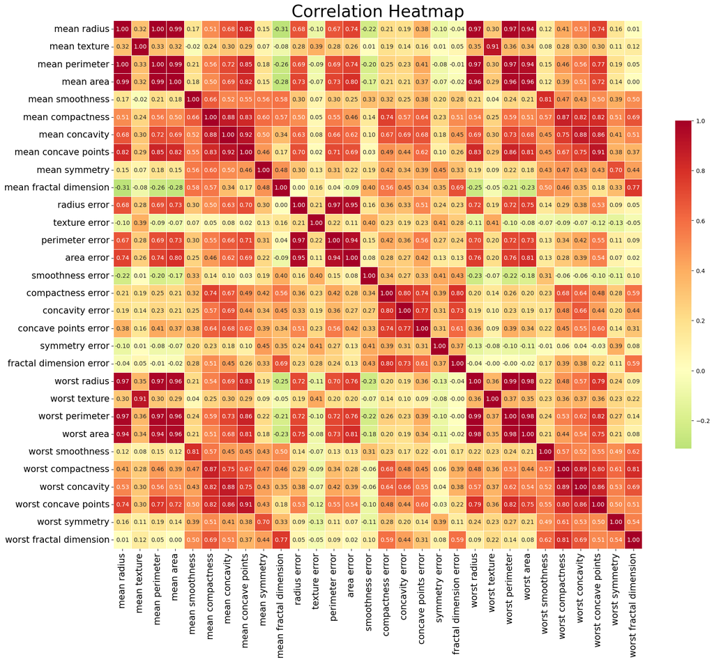

```python
# create a correlation heatmap
corr_matrix = df.drop(['id', 'diagnosis'], axis=1).corr()
plt.figure(figsize=(20,20))
plt.title('Correlation Heatmap', fontsize=28)
sns.heatmap(corr_matrix, cmap="RdYlGn_r", center=0,
            annot=True, fmt='.2f', square=True, linewidths=.5, cbar_kws={"shrink": .5})


plt.xticks(fontsize=15, rotation=90)
plt.yticks(fontsize=15, rotation=0)

plt.show()
```

As the heat map shows a lot of heat radiation oin the center of the plot which is the diagonal line that passing on the plot has the highest heat map because of th value 1 and similarly the worstr area, mean radius , mean paramter and few more show higher parameter values when compared and there are a few lower level values which show the green color in the plot.

### Train - Test split

- Use sklearn's `tran_test_split()` function to create the split.
- Use `random_state = 55` to create consistent and repeatable train-test splits.
- What is the proportion of cancer classes in train and test sets after splitting? Are they equal or very close to each other?
- What is the importance of stratified sampling?

```python
from sklearn.preprocessing import LabelBinarizer
lb = LabelBinarizer()
```

```python
y
```

```
0      M
1      M
2      M
3      M
4      M
      ..
564    M
565    M
566    M
567    M
568    B
Name: diagnosis, Length: 569, dtype: object
```

```python
# type of X_train
type(X_train)
```

[output not shown]

```python
# type of y_train
type(y_train)
```

[output not shown]

```python
# type of X_test
type(X_test)
```

[output not shown]

```python
# type of y_test
type(y_test)
```

[output not shown]

```python
y = pd.Series(y)
```

```python
y
```

```
0      M
1      M
2      M
3      M
4      M
      ..
564    M
565    M
566    M
567    M
568    B
Name: diagnosis, Length: 569, dtype: object
```

```python
# split the datasets into training and test data
X_train, X_test, y_train, y_test = train_test_split(X, y, stratify=y, random_state = 55, test_size= 0.25)
```

```python
y_train.value_counts(normalize=True)
```

```
diagnosis
B    0.626761
M    0.373239
Name: proportion, dtype: float64
```

```python
# print some information about the y_train series when converted into a data frame
pd.DataFrame(y_train).info()
```

```
<class 'pandas.core.frame.DataFrame'>
Index: 426 entries, 193 to 239
Data columns (total 1 columns):
 #   Column     Non-Null Count  Dtype
---  ------     --------------  -----
 0   diagnosis  426 non-null    object
dtypes: object(1)
memory usage: 6.7+ KB
```

```python
y_test.value_counts(normalize=True)
```

```
diagnosis
B    0.629371
M    0.370629
Name: proportion, dtype: float64
```

```python
# print some information about the y_test series when converted into a data frame
pd.DataFrame(y_test).info()
```

```
<class 'pandas.core.frame.DataFrame'>
Index: 143 entries, 276 to 112
Data columns (total 1 columns):
 #   Column     Non-Null Count  Dtype
---  ------     --------------  -----
 0   diagnosis  143 non-null    object
dtypes: object(1)
memory usage: 2.2+ KB
```

Stratified random sampling ensures that the splits keep their proportion of targets values. This is important to stay consistent with the data collected.

Now let's train a logistic regression model on the breast cancer data. This is a binary classification problem.

### Question 4 [10 points]

#### - Initiate the logistic regression classifier from the sklearn library as shown below.

- Fit the model
- Make predictions
- Calculate accuracy score. What are the **training** and **testing** accuracies of the model?
- Create confusion matrix
- Either calculate using the confusion matrix, or use the methods in `metrics` to get the following metrics on the testing set:
  - Recall (Sensitivity)
  - Specificity
  - Precision
  - False Positive Rate
  - F1 Score

```python
from sklearn.linear_model import LogisticRegression
```

```python
clf = LogisticRegression(max_iter = 10000, C=0.1)
```

```python
clf.fit(X_train, y_train)
```

```
LogisticRegression(C=0.1, max_iter=10000)
```

```python
pred = clf.predict(X_train)
metrics.accuracy_score(y_true = y_train, y_pred = pred)
```

```
0.9413145539906104
```

```python
pred = clf.predict(X_test)
metrics.accuracy_score(y_true = y_test, y_pred = pred)
```

```
0.986013986013986
```

```python
metrics.confusion_matrix(y_true=y_test, y_pred=pred)
```

```
array([[89,  1],
       [ 1, 52]], dtype=int64)
```

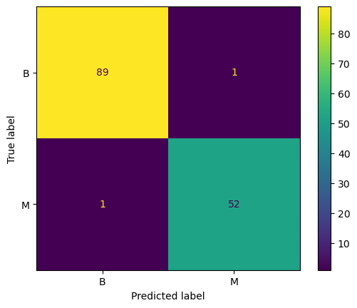

```python
confusion_matrix_train=metrics.ConfusionMatrixDisplay.from_predictions(y_true=y_test, y_pred=pred)
```

```python
print (metrics.classification_report(y_test, pred))
```

```
              precision    recall  f1-score   support

           B       0.99      0.99      0.99        90
           M       0.98      0.98      0.98        53

    accuracy                           0.99       143
   macro avg       0.99      0.99      0.99       143
weighted avg       0.99      0.99      0.99       143
```

The classification report are:

Recall is 0.98.

Specificity is 0.99.

Precision is 0.98.

False Positive Rate is 0.01.

F1 Score is 0.98.

### Question 5 [10 points]

- Initiate the k-nearest neighbours classifier from the sklearn library with n_neighbors=1. Keep the remaining parameters with their default values. (No need to specify anything)
- Fit the model
- Make predictions
- Calculate accuracy score. What are the **training** and **testing** accuracies of the model?
- Create confusion matrix
- Either calculate using the confusion matrix, or using the methods in `metrics` to get the following metrics on the testing set:
  - Recall (Sensitivity)
  - Specificity
  - Precision
  - F1 Score

```python
from sklearn.neighbors import KNeighborsClassifier
```

```python
knn_clf = KNeighborsClassifier(n_neighbors=1)
knn_clf.fit(X_train, y_train)
```

```
KNeighborsClassifier(n_neighbors=1)
```

```python
print(f"y_test shape: {y_test.shape}, type: {type(y_test)}")
print(f"knn_test shape: {knn_test.shape}, type: {type(knn_test)}")
```

[output not shown]

```python
#X_train = np.array(X_train)
#y_train = np.array(y_train)
```

```python
#X_test = np.array(X_test)
#y_test = y_test.squeeze()
```

```python
X_train_np = X_train.to_numpy() if isinstance(X_train, pd.DataFrame) else X_train
X_test_np = X_test.to_numpy() if isinstance(X_test, pd.DataFrame) else X_test

knn_pred_train = knn_clf.predict(X_train_np)
knn_pred_test = knn_clf.predict(X_test_np)
```

```python
training_accuracy = accuracy_score(y_train, knn_pred_train)
print(f"Training Accuracy: {training_accuracy}")
```

```
Training Accuracy: 1.0
```

```python
test_accuracy = accuracy_score(y_test, knn_pred_test)
print(f"Test Accuracy: {test_accuracy}")
```

```
Test Accuracy: 0.9440559440559441
```

```python
metrics.confusion_matrix(y_test, knn_pred_test)
```

```
array([[86,  4],
       [ 4, 49]], dtype=int64)
```

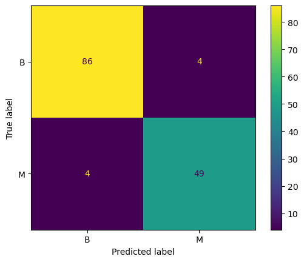

```python
confusion_matrix_new = metrics.ConfusionMatrixDisplay.from_predictions(y_test, knn_pred_test)
```

```python
print(metrics.classification_report(y_test, knn_pred_test))
```

```
              precision    recall  f1-score   support

           B       0.96      0.96      0.96        90
           M       0.92      0.92      0.92        53

    accuracy                           0.94       143
   macro avg       0.94      0.94      0.94       143
weighted avg       0.94      0.94      0.94       143
```

The classification report are:

Recall(Sensitivity) is 0.92.

Specificity is 0.96.

Precision is 0.92.

False Positive Rate is 0.04.

F1 Score is 0.92.

### Question 6 [10 points]

In logistic regression keeping the other parameters constant try these values for C: `C_list = [0.0001, 0.0005, 0.001, 0.005, 0.01, 0.05, 0.1, 0.5, 1, 2, 10, 50, 100, 200, 500, 1000, 2000, 5000, 10000]`.  
C is the inverse of the regularization parameter $\lambda$. As C increases, the penalty decreases.

- Create a loop and fit the models using each C value.
- Make predictions
- Calculate accuracy scores for **training** and **testing** datasets. Create a list of accuracy results for train and test accuracies. Show these lists.
- Create the validation curve based on each C value and the corresponding train and test accuracies.

  > Create this curve yourself. Do not use sklearn built-in function.

```python
C_list = [0.0001, 0.0005, 0.001, 0.005, 0.01, 0.05, 0.1, 0.5, 1, 2, 10, 50, 100, 200, 500, 1000, 2000, 5000, 10000]
accuracy_train = []
accuracy_test = []
for C in C_list:
    clf = LogisticRegression(max_iter = 10000, C=C)
    clf.fit(X_train, y_train)
    print('Iterations:', clf.n_iter_)

    # derive the classifier's prediction on the training set
    pred_training = clf.predict(X_train)

    # calculate the training accuracy scores and add them to the list of accuracy_train.
    accuracy_train.append(metrics.accuracy_score(y_true=y_train, y_pred=pred_training))

    # derive the classifier's prediction on the testing set
    pred_test = clf.predict(X_test)

     # calculate the testing accuracy scores and add them to the accuracy_test list.
    accuracy_test.append(metrics.accuracy_score(y_true=y_test, y_pred=pred_test))
```

```
Iterations: [91]
Iterations: [162]
Iterations: [205]
Iterations: [289]
Iterations: [268]
Iterations: [611]
Iterations: [991]
Iterations: [1891]
Iterations: [2341]
Iterations: [3359]
Iterations: [3500]
Iterations: [6763]
Iterations: [9765]
Iterations: [6111]
Iterations: [5732]
Iterations: [6920]
Iterations: [6603]
Iterations: [8725]
Iterations: [8375]
```

```python
accuracy_train
```

```
[0.9248826291079812,
 0.931924882629108,
 0.9413145539906104,
 0.9342723004694836,
 0.9389671361502347,
 0.9413145539906104,
 0.9413145539906104,
 0.9460093896713615,
 0.9436619718309859,
 0.9507042253521126,
 0.9624413145539906,
 0.9741784037558685,
 0.9812206572769953,
 0.9859154929577465,
 0.9882629107981221,
 0.9882629107981221,
 0.9882629107981221,
 0.9882629107981221,
 0.9882629107981221]
```

```python
accuracy_test
```

```
[0.9370629370629371,
 0.958041958041958,
 0.9790209790209791,
 0.972027972027972,
 0.972027972027972,
 0.9790209790209791,
 0.986013986013986,
 0.993006993006993,
 0.993006993006993,
 0.993006993006993,
 0.986013986013986,
 0.993006993006993,
 0.993006993006993,
 0.993006993006993,
 0.986013986013986,
 0.986013986013986,
 0.9790209790209791,
 0.9790209790209791,
 0.972027972027972]
```

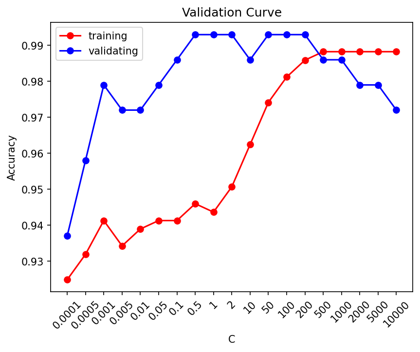

```python
f, ax = plt.subplots(dpi=150)
plt.plot(accuracy_train, marker='o', color='red', label = 'training')
plt.plot(accuracy_test, color='blue', marker='o', label = 'validating')
plt.title('Validation Curve')
plt.xticks(ticks=np.arange(len(C_list)), labels=C_list, rotation=45)
plt.xlabel('C')
plt.ylabel('Accuracy')
plt.legend()
plt.show()
```

### Question 7 [10 points]

In K Nearest Neighbors keeping the other parameters constant try these values for K (n_neighbors): `K_list = [1,3,5,7,9,15,19,25,29,35,39,45,49]`.

- Create a loop and fit the models using each K value.
- Make predictions
- Calculate accuracy scores for **training** and **testing** datasets. Create a list of accuracy results for train and test accuracies. Show these lists.
- Create the validation curve based on each K value and the corresponding train and test accuracies.

  > Create this curve yourself. Do not use sklearn built-in function.

```python
K_list = [1,3,5,7,9,15,19,25,29,35,39,45,49]
accuracy_train = []
accuracy_test = []
# Go over every K value in a loop.
for K in K_list:
    clf_two = KNeighborsClassifier(n_neighbors=K)
    clf_two.fit(X_train, y_train)

    X_train_np = np.array(X_train)
    X_test_np = np.array(X_test)
    # Predictions for training and test sets
    pred_train = clf_two.predict(X_train_np)
    pred_test = clf_two.predict(X_test_np)


    # Calculate accuracies and append to lists
    accuracy_train.append(accuracy_score(y_train, pred_train))
    accuracy_test.append(accuracy_score(y_test, pred_test))
```

```python
accuracy_train
```

```
[1.0,
 0.9483568075117371,
 0.9460093896713615,
 0.9389671361502347,
 0.931924882629108,
 0.9248826291079812,
 0.9272300469483568,
 0.9248826291079812,
 0.9225352112676056,
 0.9225352112676056,
 0.9225352112676056,
 0.9131455399061033,
 0.9084507042253521]
```

```python
accuracy_test
```

```
[0.9440559440559441,
 0.965034965034965,
 0.9370629370629371,
 0.9440559440559441,
 0.9370629370629371,
 0.9440559440559441,
 0.9440559440559441,
 0.9370629370629371,
 0.9370629370629371,
 0.9370629370629371,
 0.9300699300699301,
 0.9230769230769231,
 0.9300699300699301]
```

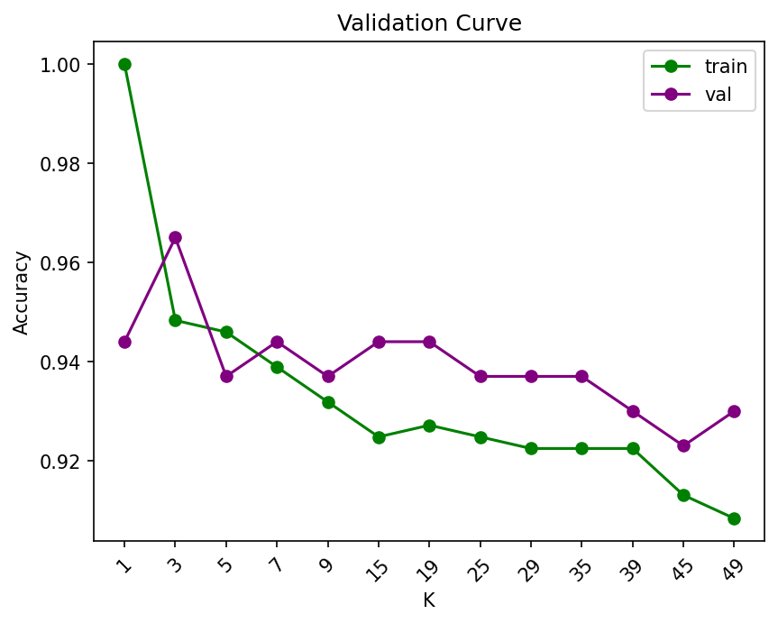

```python
f, ax = plt.subplots(dpi=150)
plt.plot(accuracy_train, marker='o', color='green', label = 'train')
plt.plot(accuracy_test, color='PURPLE', marker='o', label = 'val')
plt.title('Validation Curve')
plt.xticks(ticks=np.arange(len(K_list)), labels=K_list, rotation=45)
plt.xlabel('K')
plt.ylabel('Accuracy')
plt.legend()
plt.show()
```

### Question 8 [10 points]

- The validation curve for logistic regression seems a bit weird. That might have to do with the fact that the data is not normalized.
- Apply standardization to the data.
- In logistic regression keeping the other parameters constant try these values for C: `C_list = [0.0001, 0.0005, 0.001, 0.005, 0.01, 0.05, 0.1, 0.5, 1, 2, 10, 50, 100, 200, 500, 1000, 2000, 5000, 10000]`.
- Plot validation curves. What do you see?
- Which value would you choose for C in logistic regression?

```python
from sklearn import preprocessing
```

```python
ss = preprocessing.StandardScaler()
X_train_ss = ss.fit_transform(X_train)
X_test_ss = ss.transform(X_test)
```

```python
X_train_ss.shape
```

```
(426, 30)
```

```python
X_test_ss.shape
```

```
(143, 30)
```

```python
C_list = [0.0001, 0.0005, 0.001, 0.005, 0.01, 0.05, 0.1, 0.5, 1, 2, 10, 50, 100, 200, 500, 1000, 2000, 5000, 10000]
accuracy_train = []
accuracy_test = []
for C in C_list:
    clf = LogisticRegression(max_iter = 10000, solver='lbfgs', penalty='l2', C=C)
    # fit the model on the training set
    clf.fit(X_train_ss, y_train)
    print('Iterations:', clf.n_iter_)

    # derive the classifier's prediction on the training set
    pred_train = clf.predict(X_train_ss)

    # calculate the training accuracy scores and add them to the list of accuracy_train.
    accuracy_train.append(metrics.accuracy_score(y_true=y_train, y_pred=pred_train))

    # derive the classifier's prediction on the testing set
    pred_test = clf.predict(X_test_ss)

    # calculate the testing accuracy scores and add them to the accuracy_test list.
    accuracy_test.append(metrics.accuracy_score(y_true=y_test, y_pred=pred_test))
Iterations: [10]
```

```
Iterations: [10]
Iterations: [11]
Iterations: [11]
Iterations: [12]
Iterations: [12]
Iterations: [16]
Iterations: [17]
Iterations: [25]
Iterations: [32]
Iterations: [42]
Iterations: [75]
Iterations: [140]
Iterations: [169]
Iterations: [218]
Iterations: [335]
Iterations: [470]
Iterations: [564]
Iterations: [646]
Iterations: [659]
```

```python
accuracy_train
```

```
[0.6455399061032864,
 0.8356807511737089,
 0.8849765258215962,
 0.9460093896713615,
 0.9483568075117371,
 0.9788732394366197,
 0.9835680751173709,
 0.9906103286384976,
 0.9906103286384976,
 0.9929577464788732,
 0.9929577464788732,
 0.9929577464788732,
 0.9929577464788732,
 0.9953051643192489,
 0.9976525821596244,
 0.9976525821596244,
 1.0,
 1.0,
 1.0]
```

```python
accuracy_test
```

```
[0.6363636363636364,
 0.8671328671328671,
 0.9300699300699301,
 0.965034965034965,
 0.965034965034965,
 0.9790209790209791,
 0.986013986013986,
 0.986013986013986,
 0.9790209790209791,
 0.9790209790209791,
 0.9790209790209791,
 0.972027972027972,
 0.972027972027972,
 0.972027972027972,
 0.972027972027972,
 0.965034965034965,
 0.965034965034965,
 0.965034965034965,
 0.965034965034965]
```

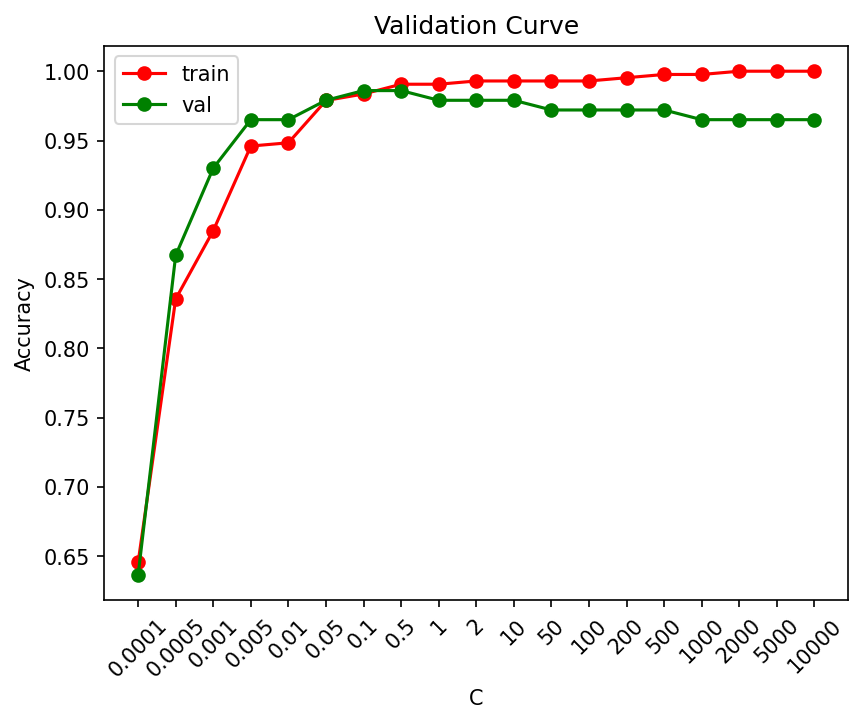

```python
f, ax = plt.subplots(dpi=150)
plt.plot(accuracy_train, marker='o', color='red', label = 'train')
plt.plot(accuracy_test, color='green', marker='o', label = 'val')
plt.title('Validation Curve')
plt.xticks(ticks=np.arange(len(C_list)), labels=C_list, rotation=45)
plt.xlabel('C')
plt.ylabel('Accuracy')
plt.legend()
plt.show()
```

### Question 9 [10 points]

- After choosing your best C value, let's check the learning curve.
- Create a logistic regression model of your chosen C value.
- Starting from 10 data points in the training set, increase your training set size by 1 points in each iteration, fit the model, get the accuracy scores for both the current training and test sets.
- Increase the training set size consecutively. Do not randomly select data points. (`X_train_ss[0:N,:] where N = {1,2,3,...,len(X_train_ss)}`)
- Plot the learning curve. What do you see? Comment on your finding.

```python
X_train_ss.shape
```

```
(426, 30)
```

```python
# list(range(1, X_train_ss.shape[0]))
n=1
X_train_ss[0:n,:]
```

```
array([[-0.50323613,  1.73953408, -0.44053352, -0.49664617,  0.53358854,
         0.59839524,  0.25384105, -0.07259947,  0.47589812,  0.94655516,
         0.01943197,  1.10918571, -0.08331186, -0.11344568,  0.73341644,
         0.68332997,  0.17965816,  0.26900086, -0.2116796 ,  0.6599449 ,
        -0.12918496,  2.17946516, -0.1622508 , -0.19511526,  1.9967161 ,
         1.31027091,  0.79584853,  0.47330699,  0.45100311,  1.90561739]])
```

```python
y_train
```

```
193    M
543    B
255    M
142    B
330    M
      ..
167    M
73     M
366    M
245    B
239    M
Name: diagnosis, Length: 426, dtype: object
```

```python
accuracy_train = []
accuracy_test = []
for n in range(10, X_train_ss.shape[0]):
    clf = LogisticRegression(max_iter = 100, solver='lbfgs', penalty='l2', C=0.5, verbose=0)
    clf.fit(X_train_ss[0:n,:], y_train[0:n])
    pred_trn = clf.predict(X_train_ss[0:n,:])
    accuracy_train.append(metrics.accuracy_score(y_true = y_train[0:n], y_pred = pred_trn))
    pred_tst = clf.predict(X_test_ss)
    accuracy_test.append(metrics.accuracy_score(y_true = y_test, y_pred = pred_tst))
```

```python
accuracy_train = []
accuracy_test = []
training_sizes = range(10, len(X_train_ss) + 1)  # Corrected to include the last size

for n in training_sizes:
    # Fit model on the current subset of the training data
    clf = LogisticRegression(max_iter=10000, solver='lbfgs', penalty='l2', C=0.5)
    clf.fit(X_train_ss[:n, :], y_train[:n])

    # Predict and calculate accuracy on the current training subset
    pred_train = clf.predict(X_train_ss[:n, :])
    accuracy_train.append(accuracy_score(y_train[:n], pred_train))

    # Predict and calculate accuracy on the entire test set
    pred_test = clf.predict(X_test_ss)
    accuracy_test.append(accuracy_score(y_test, pred_test))
```

```python
print(pred_train)
```

```
['M' 'B' 'M' 'B' 'M' 'M' 'M' 'B' 'B' 'B' 'B' 'B' 'M' 'B' 'B' 'M' 'B' 'M'
 'M' 'B' 'B' 'B' 'B' 'M' 'M' 'B' 'B' 'B' 'B' 'M' 'M' 'B' 'M' 'M' 'B' 'B'
 'M' 'B' 'B' 'B' 'M' 'B' 'M' 'B' 'B' 'B' 'B' 'M' 'B' 'M' 'B' 'B' 'B' 'B'
 'B' 'M' 'M' 'B' 'B' 'B' 'M' 'M' 'B' 'B' 'M' 'B' 'B' 'M' 'M' 'B' 'M' 'B'
 'B' 'B' 'B' 'B' 'B' 'M' 'M' 'M' 'B' 'M' 'B' 'B' 'B' 'B' 'B' 'B' 'M' 'M'
 'B' 'B' 'B' 'B' 'B' 'B' 'B' 'B' 'B' 'B' 'B' 'M' 'M' 'B' 'B' 'M' 'M' 'B'
 'M' 'M' 'B' 'M' 'M' 'M' 'M' 'M' 'B' 'B' 'B' 'B' 'B' 'B' 'M' 'B' 'M' 'B'
 'B' 'B' 'B' 'M' 'B' 'B' 'M' 'B' 'M' 'M' 'M' 'M' 'M' 'B' 'B' 'B' 'B' 'B'
 'B' 'B' 'M' 'B' 'M' 'M' 'M' 'M' 'M' 'B' 'B' 'B' 'B' 'B' 'B' 'B' 'M' 'M'
 'B' 'B' 'B' 'M' 'B' 'M' 'B' 'M' 'M' 'M' 'B' 'M' 'B' 'M' 'M' 'B' 'M' 'B'
 'M' 'B' 'B' 'B' 'M' 'M' 'M' 'M' 'B' 'M' 'B' 'B' 'M' 'B' 'B' 'M' 'B' 'B'
 'M' 'B' 'B' 'B' 'M' 'M' 'B' 'B' 'M' 'B' 'B' 'B' 'B' 'B' 'M' 'M' 'M' 'M'
 'B' 'B' 'B' 'B' 'B' 'M' 'B' 'B' 'B' 'B' 'B' 'B' 'B' 'B' 'B' 'M' 'M' 'B'
 'B' 'B' 'B' 'M' 'B' 'M' 'B' 'B' 'M' 'B' 'B' 'M' 'M' 'B' 'M' 'M' 'M' 'B'
 'B' 'B' 'B' 'B' 'B' 'M' 'B' 'B' 'B' 'M' 'B' 'B' 'B' 'B' 'M' 'M' 'B' 'B'
 'B' 'B' 'M' 'M' 'M' 'B' 'B' 'M' 'M' 'B' 'M' 'B' 'B' 'B' 'B' 'M' 'B' 'M'
 'B' 'B' 'B' 'M' 'M' 'B' 'B' 'B' 'B' 'B' 'M' 'B' 'M' 'B' 'B' 'B' 'B' 'B'
 'M' 'B' 'B' 'B' 'B' 'B' 'M' 'B' 'M' 'M' 'B' 'B' 'M' 'B' 'B' 'B' 'M' 'M'
 'B' 'M' 'B' 'B' 'B' 'B' 'B' 'B' 'B' 'M' 'B' 'B' 'M' 'B' 'M' 'M' 'M' 'B'
 'M' 'B' 'B' 'B' 'B' 'M' 'M' 'B' 'B' 'M' 'B' 'M' 'B' 'B' 'B' 'M' 'B' 'M'
 'B' 'B' 'M' 'M' 'B' 'B' 'M' 'B' 'B' 'B' 'M' 'B' 'B' 'B' 'M' 'B' 'B' 'B'
 'M' 'B' 'B' 'B' 'M' 'B' 'M' 'B' 'M' 'B' 'M' 'M' 'B' 'B' 'B' 'M' 'B' 'B'
 'M' 'B' 'B' 'B' 'M' 'B' 'B' 'B' 'B' 'B' 'B' 'B' 'M' 'B' 'B' 'M' 'B' 'M'
 'M' 'B' 'B' 'B' 'M' 'B' 'M' 'M' 'B' 'M' 'B' 'M']
```

```python
print(pred_test)
```

```
['B' 'B' 'M' 'B' 'M' 'M' 'B' 'B' 'B' 'B' 'B' 'M' 'M' 'B' 'M' 'B' 'B' 'B'
 'B' 'M' 'B' 'M' 'B' 'M' 'B' 'B' 'B' 'B' 'B' 'M' 'B' 'B' 'B' 'B' 'M' 'M'
 'M' 'M' 'B' 'M' 'B' 'B' 'M' 'M' 'M' 'B' 'M' 'B' 'M' 'B' 'B' 'B' 'B' 'B'
 'B' 'M' 'M' 'M' 'B' 'B' 'B' 'B' 'B' 'B' 'B' 'M' 'B' 'B' 'B' 'M' 'B' 'B'
 'M' 'M' 'B' 'B' 'B' 'M' 'B' 'B' 'B' 'M' 'B' 'B' 'M' 'B' 'M' 'B' 'B' 'B'
 'B' 'M' 'M' 'M' 'B' 'B' 'B' 'M' 'B' 'B' 'M' 'M' 'M' 'B' 'M' 'B' 'M' 'B'
 'B' 'B' 'B' 'B' 'B' 'B' 'M' 'B' 'B' 'M' 'B' 'B' 'M' 'M' 'B' 'M' 'B' 'B'
 'B' 'B' 'B' 'M' 'B' 'B' 'M' 'B' 'B' 'B' 'M' 'M' 'B' 'M' 'B' 'M' 'B']
```

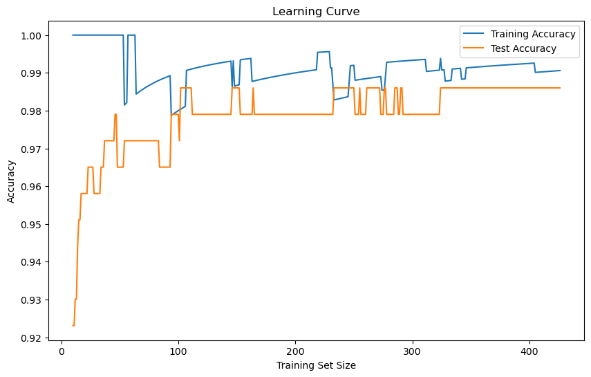

```python
plt.figure(figsize=(10, 6))
plt.plot(training_sizes, accuracy_train, label='Training Accuracy')
plt.plot(training_sizes, accuracy_test, label='Test Accuracy')
plt.xlabel('Training Set Size')
plt.ylabel('Accuracy')
plt.title('Learning Curve')
plt.legend()
plt.show()
```

### Question 10 [20 points]

- Think of other ways of improving the accuracy and list at least two possibilities.
- Implement both the methods you proposed.
- Is the model accuracy increasing? Why do you think this might have helped?
- If both of them did not impove, can you think of anything else? (Optional to apply)

1] SVM

```python
scaler = StandardScaler()
X_train_scaled = scaler.fit_transform(X_train)
X_test_scaled = scaler.transform(X_test)


# Fit the SVM model
model = SVC(kernel='sigmoid')
model.fit(X_train_scaled, y_train)

# Make predictions
y_pred = model.predict(X_test_scaled)
print(y_pred)
```

```
['B' 'B' 'M' 'B' 'M' 'M' 'B' 'B' 'B' 'B' 'B' 'M' 'M' 'B' 'B' 'B' 'B' 'B'
 'B' 'M' 'M' 'M' 'B' 'M' 'B' 'B' 'B' 'B' 'B' 'M' 'B' 'B' 'B' 'B' 'M' 'M'
 'M' 'M' 'B' 'M' 'B' 'B' 'M' 'M' 'M' 'B' 'M' 'B' 'M' 'B' 'B' 'B' 'B' 'B'
 'B' 'M' 'M' 'M' 'B' 'B' 'B' 'B' 'B' 'B' 'B' 'M' 'B' 'B' 'B' 'M' 'B' 'B'
 'M' 'M' 'B' 'B' 'B' 'M' 'B' 'B' 'B' 'M' 'B' 'B' 'M' 'B' 'M' 'B' 'B' 'B'
 'B' 'M' 'M' 'M' 'B' 'B' 'B' 'M' 'M' 'B' 'M' 'M' 'M' 'B' 'M' 'B' 'M' 'B'
 'B' 'B' 'B' 'B' 'B' 'B' 'M' 'B' 'B' 'M' 'B' 'B' 'M' 'M' 'B' 'M' 'B' 'B'
 'B' 'B' 'B' 'M' 'B' 'B' 'M' 'B' 'B' 'B' 'M' 'M' 'B' 'M' 'B' 'M' 'B']
```

```python
# Calculate accuracy score
accuracy = accuracy_score(y_test, y_pred)
print(f"Accuracy: {accuracy}")
```

```
Accuracy: 0.965034965034965
```

```python
# Create confusion matrix and print it
cm = confusion_matrix(y_test, y_pred)
print("Confusion Matrix:")
print(cm)
```

```
Confusion Matrix:
[[88  2]
 [ 3 50]]
```

```
<sklearn.metrics._plot.confusion_matrix.ConfusionMatrixDisplay at 0x163e2a9d650>
```

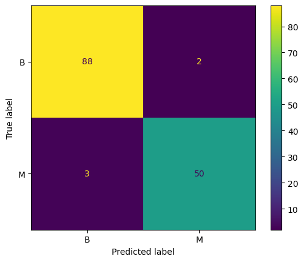

```python
metrics.ConfusionMatrixDisplay.from_predictions(y_test, y_pred)
```

```python
# Calculate additional metrics and print them
report = classification_report(y_test, y_pred, target_names=['Class 0', 'Class 1'])
print("Classification Report:")
print(report)
```

```
Classification Report:
              precision    recall  f1-score   support

     Class 0       0.97      0.98      0.97        90
     Class 1       0.96      0.94      0.95        53

    accuracy                           0.97       143
   macro avg       0.96      0.96      0.96       143
weighted avg       0.96      0.97      0.96       143
```

It has slightly higher accuracy than even KNN CLassifer the f1 score is 0.96, the accuracy is 0.97 and the recall also is close to 0.97

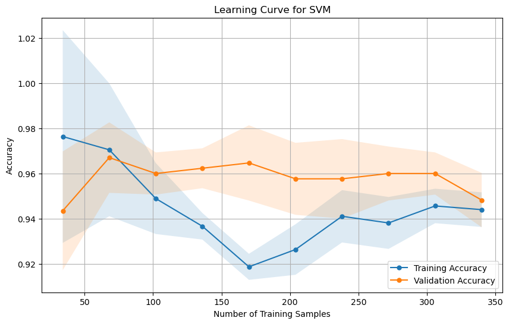

```python
train_sizes, train_scores, test_scores = learning_curve(
    model, X_train_scaled, y_train, cv=5, scoring='accuracy', train_sizes=np.linspace(0.1, 1.0, 10))

train_mean = np.mean(train_scores, axis=1)
train_std = np.std(train_scores, axis=1)
test_mean = np.mean(test_scores, axis=1)
test_std = np.std(test_scores, axis=1)

# Create a plot for the learning curve
plt.figure(figsize=(10, 6))
plt.plot(train_sizes, train_mean, label='Training Accuracy', marker='o', markersize=5)
plt.fill_between(train_sizes, train_mean - train_std, train_mean + train_std, alpha=0.15)
plt.plot(train_sizes, test_mean, label='Validation Accuracy', marker='o', markersize=5)
plt.fill_between(train_sizes, test_mean - test_std, test_mean + test_std, alpha=0.15)
plt.xlabel('Number of Training Samples')
plt.ylabel('Accuracy')
plt.legend(loc='lower right')
plt.title('Learning Curve for SVM')
plt.grid()
plt.show()
```

2] Using gridsearch with Svm Classifier.

I'am using a 5 fold technique here to take all the c values, gamma values and adjust the requirments. Hence the accuracy of the model using with grid fol using SVM will achieve almost 98% accuracy better than even svm and also knn classifer. and the results of the classifaction metrics shows it all.

```python
scaler = StandardScaler()
X_train_scaled = scaler.fit_transform(X_train)
X_test_scaled = scaler.transform(X_test)

svm_classifier = SVC()
stratified_kfold = StratifiedKFold(n_splits=5, shuffle=True, random_state=42)
```

```python
param_grid = {
    'kernel': ['linear', 'rbf', 'poly', 'sigmoid'],  # You can add other kernels as needed
    'C': [0.1, 1, 10, 100],  # Adjust the range of C values
    'gamma': ['scale', 'auto', 0.1, 1, 10]  # Adjust the range of gamma values
}
```

```python
# Create a GridSearchCV object with 5-fold cross-validation
grid_search = GridSearchCV(estimator=svm_classifier, param_grid=param_grid, scoring='accuracy', cv=5)
```

```python
# Perform grid search to find the best hyperparameters
grid_search.fit(X_train_scaled, y_train)

# Print the best hyperparameters and corresponding accuracy
best_params = grid_search.best_params_
best_accuracy = grid_search.best_score_
```

```python
print("Best Hyperparameters:", best_params)
print("Best Accuracy:", best_accuracy)
```

```
Best Hyperparameters: {'C': 0.1, 'gamma': 'scale', 'kernel': 'linear'}
Best Accuracy: 0.9765253077975377
```

```python
# Get the best SVM model with optimized hyperparameters
best_svm_classifier = grid_search.best_estimator_
```

```python
# Evaluate the best model on the test data
y_pred = best_svm_classifier.predict(X_test_scaled)
test_accuracy = accuracy_score(y_test, y_pred)
```

```python
print("Test Accuracy with Best Model:", test_accuracy)
```

```
Test Accuracy with Best Model: 0.986013986013986
```

```python
cm = confusion_matrix(y_test, y_pred)
print("Confusion Matrix:")
print(cm)
```

```
Confusion Matrix:
[[90  0]
 [ 2 51]]
```

[figure not shown]

```python
# Plot Confusion Matrix
plt.figure(figsize=(8, 6))
plt.imshow(cm, interpolation='nearest', cmap=plt.cm.Blues)
plt.title('Confusion Matrix')
plt.colorbar()
tick_marks = np.arange(len(set(y_test)))
plt.xticks(tick_marks, set(y_test), rotation=45)
plt.yticks(tick_marks, set(y_test))
plt.tight_layout()
plt.xlabel('Predicted Label')
plt.ylabel('True Label')
```

```python
# Calculate additional metrics and print them
report = classification_report(y_test, y_pred, target_names=['Class 0', 'Class 1'])
print("Classification Report:")
print(report)
```

```
Classification Report:
              precision    recall  f1-score   support

     Class 0       0.98      1.00      0.99        90
     Class 1       1.00      0.96      0.98        53

    accuracy                           0.99       143
   macro avg       0.99      0.98      0.98       143
weighted avg       0.99      0.99      0.99       143
```

```python
# Generate a learning curve for the best SVM model
train_sizes, train_scores, test_scores = learning_curve(
    best_svm_classifier, X_train_scaled, y_train, cv=5, scoring='accuracy', train_sizes=np.linspace(0.1, 1.0, 10))
```

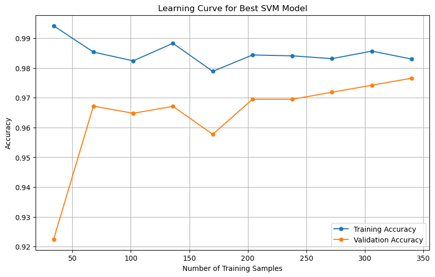

```python
# Create a plot for the learning curve
plt.figure(figsize=(10, 6))
plt.plot(train_sizes, np.mean(train_scores, axis=1), label='Training Accuracy', marker='o', markersize=5)
plt.plot(train_sizes, np.mean(test_scores, axis=1), label='Validation Accuracy', marker='o', markersize=5)
plt.xlabel('Number of Training Samples')
plt.ylabel('Accuracy')
plt.legend(loc='lower right')
plt.title('Learning Curve for Best SVM Model')
plt.grid()
plt.show()
```

In the newer model, precision for Class 0 has increased to 0.98, indicating a higher rate of correctly identified Class 0 instances, while recall for Class 1 remains high at 0.96, indicating effective identification of Class 1 instances. This balance results in an impressive F1-score for both classes.

The overall accuracy of the newer model has reached 0.99, demonstrating its ability to correctly classify the majority of instances in the dataset.